# Tidy Tuesday #1

Erin Franke

5/24/2021

### Mario Kart 64 Tidy Tuesday Plot

Load packages and the Mario Kart data from Github.

```r
library(readr)
library(dplyr)
library(ggplot2)
library(tidytuesdayR)
library(tidyverse)
library(ggthemes)
records <- readr::read_csv('https://raw.githubusercontent.com/rfordatascience/tidytuesday/master/data/2021/2021-05-25/records.csv')
drivers <- readr::read_csv('https://raw.githubusercontent.com/rfordatascience/tidytuesday/master/data/2021/2021-05-25/drivers.csv')
```

**Question: “How much faster is the single lap record (multiplied 3x) than the 3 lap course record for each of the 16 Mario Kart 64 courses? Specifically, is this difference greater for longer courses than shorter courses?”**

Create table of three lap records, filtering out any records made using a shortcut.

```r
(threelaprecords <- records %>%
  filter(type == "Three Lap", shortcut == "No") %>%
  group_by(track) %>%
  summarize(minTime = min(time, na.rm = TRUE)) %>%
  arrange(desc(minTime)))
```

| track | minTime |
| --- | --- |
| Rainbow Road | 351.87 |
| Wario Stadium | 260.01 |
| Toad's Turnpike | 177.80 |
| Royal Raceway | 171.25 |
| Bowser's Castle | 132.00 |
| D.K.'s Jungle Parkway | 131.62 |
| Banshee Boardwalk | 124.09 |
| Kalimari Desert | 123.94 |
| Frappe Snowland | 119.95 |
| Luigi Raceway | 117.77 |

[output cut: 6 more lines]

Create table of one lap records, and multiply by three. Again filter out any records made with a shortcut.

```r
onelaprecords <- records %>%
  filter(type == "Single Lap", shortcut == "No") %>%
  group_by(track) %>%
  summarize(singlelap = min(time, na.rm = TRUE)) %>%
  arrange(desc(singlelap))

(records1lap3x <- onelaprecords %>%
  mutate(singlelap3x = singlelap * 3) %>%
  select(track, singlelap3x))
```

| track | singlelap3x |
| --- | --- |
| Rainbow Road | 349.05 |
| Wario Stadium | 257.46 |
| Toad's Turnpike | 176.07 |
| Royal Raceway | 166.50 |
| Bowser's Castle | 129.45 |
| D.K.'s Jungle Parkway | 126.12 |
| Banshee Boardwalk | 122.34 |
| Kalimari Desert | 116.88 |
| Frappe Snowland | 114.81 |
| Choco Mountain | 114.06 |

[output cut: 6 more lines]

Join the tables and create a column called “difference” which is how much faster the single lap record (multiplied 3x) is than the three lap course record. Additionally, I created a column called “Course Length”, which denotes a course as short, medium, or long based on the three lap record.  
Long courses: Three Lap Record greater than 170 seconds  
Medium courses: Three Lap Record between 115-135 seconds  
Short courses: Three Lap Record less than 105 seconds

```r
differences <- threelaprecords %>%
  full_join(records1lap3x, by = "track")%>%
  rename(`Three Lap Record` = `minTime`) %>%
  rename(`One Lap Record (3x)` = `singlelap3x`) %>%
  mutate(difference = `Three Lap Record` - `One Lap Record (3x)`) %>%
  mutate(`Course Length` = `Three Lap Record`)

differences$`Course Length` <- cut(differences$`Course Length`,
                   breaks=c(-Inf, 115, 133, Inf),
                   labels=c("short (<105 seconds)","medium (115-135 seconds)","long (>170 seconds)"))
differences
```

| track | Three Lap Record | One Lap Record (3x) | difference | Course Length |
| --- | --- | --- | --- | --- |
| Rainbow Road | 351.87 | 349.05 | 2.82 | long (>170 seconds) |
| Wario Stadium | 260.01 | 257.46 | 2.55 | long (>170 seconds) |
| Toad's Turnpike | 177.80 | 176.07 | 1.73 | long (>170 seconds) |
| Royal Raceway | 171.25 | 166.50 | 4.75 | long (>170 seconds) |
| Bowser's Castle | 132.00 | 129.45 | 2.55 | medium (115-135 seconds) |
| D.K.'s Jungle Parkway | 131.62 | 126.12 | 5.50 | medium (115-135 seconds) |
| Banshee Boardwalk | 124.09 | 122.34 | 1.75 | medium (115-135 seconds) |
| Kalimari Desert | 123.94 | 116.88 | 7.06 | medium (115-135 seconds) |
| Frappe Snowland | 119.95 | 114.81 | 5.14 | medium (115-135 seconds) |
| Luigi Raceway | 117.77 | 112.74 | 5.03 | medium (115-135 seconds) |

[output cut: 6 more lines]

Create the bar plot, coloring each bar by course length.

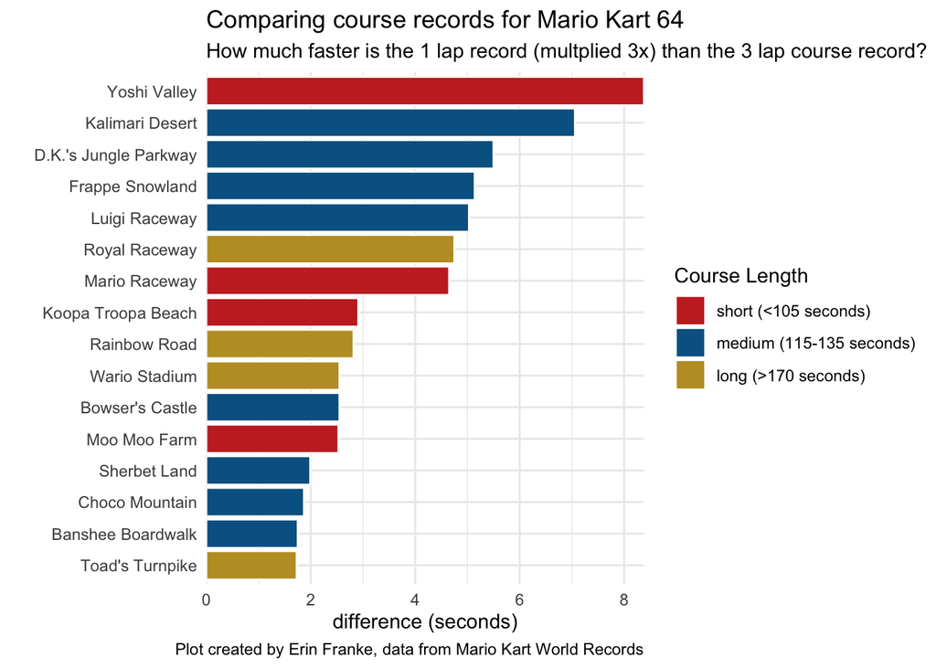

```r
differences %>%
  ggplot(aes(x=difference, y=fct_reorder(track, difference), fill = `Course Length`))+
  geom_col(color = "white") +
  theme_minimal() +
  labs(title = "Comparing course records for Mario Kart 64", subtitle = "How much faster is the 1 lap record (multplied 3x) than the 3 lap course record?", y = "", caption = "Plot created by Erin Franke, data from Mario Kart World Records", x= "difference (seconds)") +
  scale_x_continuous(expand = c(0,0))+
  scale_fill_wsj()
```

### Plot made with group in class:

**Research question: Which track is the fastest during a three lap, no shortcuts race?**

Filter the data

```r
records_filtered <- records %>%
  filter(type == "Three Lap", shortcut == "No") %>%
  group_by(track, system_played) %>%
  summarize(recordtime = min(time, na.rm=TRUE))
```

Create plot

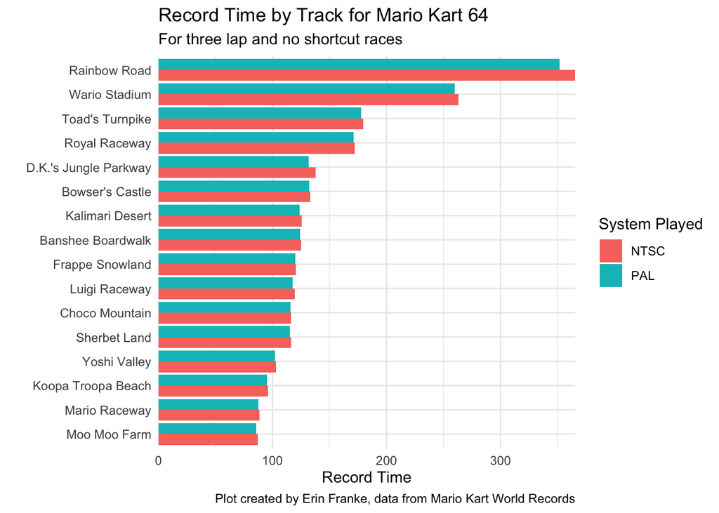

```r
records_filtered %>%
  ggplot(mapping = aes(x=recordtime, y=fct_reorder(track,recordtime), fill=system_played)) +
  geom_col(position = "dodge") +
  labs(x= "Record Time", fill = "System Played", y = "", title = "Record Time by Track for Mario Kart 64", subtitle = "For three lap and no shortcut races", caption = "Plot created by Erin Franke, data from Mario Kart World Records")+
  scale_x_continuous(expand = c(0,0))+
  theme_minimal()
```